# **Pueblo indigena**

## **Garifunas de Honduras**

Los *garifunas* son un pueblo indígena que habitan en la costa atlántica, en honduras existen unos 98,000 aproximadamente, extensos grupos de garifunas existen en las ciudades mas importantes de honduras, se concentran en la costa norte del país y por la ubicación de zona tropical gozan de un clima cálido.

### Aspectos socio-cultural y religiosos

Las características socioculturales de esta población se pueden notar en las estructuras sociales y familiares ya que no han surgido cambios a lo largo del tiempo porque han cuidado muchisimo que no hayan interelaciones con otros pueblos indígenas.Los garifunas llevan creando su cultura más de 300 años y cambiando de acuerdo a sus necesidades y conforme se han involucrado con otras poblaciones, comparten mucho con indígenas de la selva amazónica como: *la lengua, el baile,prácticas y creencias religiosas, alimentación y la pesca.* Pero sus antepasados africanos también dejaron una huella en el estilo del baile, sus culltivos y alimentación. Los europeos aportaron y modificaron mucho a esas cosas de su cultura como: muebles de casa, religión, hábitos alimenticios, estilos de vestir y folklore conservando mucho de lo ancestral.

Los mecanismos garífunas reflejan una herencia ancestral, legado de la cultura arawaka caribe de las Guayanas y de la cuenca del Amazonas, además de su pasado africano y al aporte de la cultura hispanoamericano.La mayoría de los garifunas no sólo habla el castellano sino que practican la mayoria el catolicismo es decir su religión pero no se cierran a aprender de las enseñanzas católicas y mantienen muy vivas sus creencias religiosas afro-indianas.

Las principales características de los garifunas incluyen: un lenguaje de origen amerindio con cierta influencia francesa, española e inglesa; un elaborado culto ancestral cuyos ritos están a cargo de curanderos, además del español los garifunas siguen hablando su lengua y mantienen sus costumbres y tradiciones de su mezcla afro-indígena. Según los investigadores es una mezcla de otras lenguas como por ejemplo:

- arawak
- Francés
- Yoruba
- Swahili
- Bantu

La palabra garifuna no define solamente el idioma si no a la gente que lo habla para diferenciar de los que solo hablan inglés.

Las familias son muy recurrentes a la migración y las parejas suelen estar juntos por sus hijos, los mayores desajustes familiares suelen pasar por pobreza o el poder adquisitivo de bienes de consumo lo que suele provocar también la separación conyugal.

La mayoría de sus comunidades están pasando un fuerte proceso de desculturación, principalmente entre su juventud. Sólo algunas comunidades, desde Punta Piedra hasta Plaplaya, conservan y valoran su cultura. Los clubes de cultura son los que han asumido la tarea de revitalizar y dar a conocer la cultura garífuna. Las actividades se centran en el rescate y la promoción de los valores culturales, sobre todo entre los jóvenes.

Esta cultura es interesante porque estan pasando por un momento de rechazo de las figuras de poder expresada por obligarlos a moverse talando sus bosques con fines turisticos, sin embargo usualmente los contratos de construcción de los terrenos son de empresas trasnacionales.

[figure not shown]

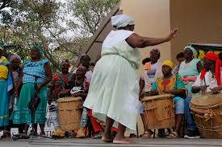

Imagen remota

[Fuente de información](https://repository.ubn.ru.nl/bitstream/handle/2066/145805/mmubn000001_182717151.pdf)